# IMPORTANT: `darts` is only installed on the `timeseries_env`. This will not work on `base`

# Goal for this Notebook

The purpose of this notebook is to develop a working forecast model for Call and Chat volume at the weekly level. Once a good working model is selected, it should be transferred to a separate file to be put into production.

```python
import matplotlib.pyplot as plt

import seaborn as sns
import pandas as pd
import numpy as np
from datetime import datetime

# new library to test: darts
import darts
import darts.metrics as met
import darts.models as mod

# for ARIMA optimization
import pmdarima as pmd

from sqlalchemy import create_engine
```

```python
# create SQL connection to the network services db here
# create connection
server = 'CMMSQLRPT2'
db = 'network_services'
driver = 'SQL+Server'
conn_str = 'mssql+pyodbc://{}/{}?driver={}'.format(server,db,driver)
engine = create_engine(conn_str)
```

```python
# get the data
# NOTE: this query has been slightly modified (the final WHERE clause) to ensure replicability if this program is run later

query = '''

--------------------------------------
-- get initial call data
with get_calls as (
	select call_id
		, call_datetime
		,cast(call_datetime as date) as date
		,DATEADD(mi,
			(DATEPART(mi, call_datetime)/30)*30,
			DATEADD(hour,datediff(hour,0,call_datetime),0)) as bucket
	from t_ns_calls
	where call_type = 'Inbound'
		and (
			(datepart(dw, call_datetime) = 7
			and datepart(hh, call_datetime) between 8 and 17)
		or  (datepart(dw, call_datetime) between 2 and 6
			and datepart(hh, call_datetime) between 8 and 22)
			)
	)

-- total call data by bucket
, call_buckets as (
	select
		'Actual' as series
		,DATEADD(ww,DATEDIFF(ww,0,bucket),-1) as weekstart  --use -1 as the starting point since date 0 is a Monday (so this will give us weekstart as Sunday)
		,max(date) as date
		,bucket
		,'Call' as interaction_type
		,DATEPART(dw, bucket) as day_of_week
		,COUNT(distinct call_id) as n_calls
	from get_calls
	group by bucket
	)

--------------------------------------
-- get initial chat data
, get_chats as (
	select
		chat_id
		,conversation_sequence
		,conversation_start_time
		,cast(conversation_start_time as date) as date
		,DATEADD(mi,
			(DATEPART(mi, conversation_start_time)/30)*30,
			DATEADD(hour,datediff(hour,0,conversation_start_time),0)) as bucket
	from t_ns_chats
	where num_coord_messages > 0
		and conversation_start_time > '2020-01-06 00:00:00.000' -- added to filter the initial partial week of data
		and (
			(datepart(dw, conversation_start_time) = 7
			and datepart(hh, conversation_start_time) between 8 and 17)
		or  (datepart(dw, conversation_start_time) between 2 and 6
			and datepart(hh, conversation_start_time) between 8 and 22)
			)
	)

-- total chat data by bucket
, chat_buckets as (
	select
		'Actual' as series
		,DATEADD(ww,DATEDIFF(ww,0,bucket),-1) as weekstart  --use -1 as the starting point since date 0 is a Monday (so this will give us weekstart as Sunday)
		,max(date) as date
		,bucket
		,'Chat' as interaction_type
		,DATEPART(dw, bucket) as day_of_week
		,COUNT(chat_id) as n_chats
	from get_chats
	group by bucket
	)





-------------------------------------------------------------------------------------------
---------------------------------- END CTE TABLES -----------------------------------------
-------------------------------------------------------------------------------------------
-- Single query to combine all
select t1.*
	,t2.isHoliday as is_holiday
	,t2.isWorkday as is_workday
	,t2.dayname
from (
	select
		weekstart
		,date
		,bucket
		,day_of_week
		,interaction_type
		,n_calls as volume
		from call_buckets
	UNION ALL
	select
		weekstart
		,date
		,bucket
		,day_of_week
		,interaction_type
		,n_chats as volume
		from chat_buckets
	) t1
left join common.dbo.Calendar t2
on t1. date = t2.dt
where t1.weekstart < '2023-01-01' -- replaced the line below so that any future queries will result in the same data pull
    --DATEADD(ww,DATEDIFF(ww,0,getdate()),-1) -- drop data from the current (partial) week
order by t1.bucket
'''

raw_df = pd.read_sql(query,engine)
raw_df.sample(10)
```

|  | weekstart | date | bucket | day_of_week | interaction_type | volume | is_holiday | is_workday | dayname |
| --- | --- | --- | --- | --- | --- | --- | --- | --- | --- |
| 7030 | 2020-10-25 | 2020-10-29 | 2020-10-29 13:00:00 | 5 | Chat | 143 | False | True | Thursday |
| 14170 | 2021-04-04 | 2021-04-05 | 2021-04-05 11:30:00 | 2 | Chat | 177 | False | True | Monday |
| 41953 | 2022-11-20 | 2022-11-26 | 2022-11-26 16:00:00 | 7 | Chat | 4 | False | False | Saturday |
| 10839 | 2021-01-24 | 2021-01-25 | 2021-01-25 08:00:00 | 2 | Call | 23 | False | True | Monday |
| 6540 | 2020-10-04 | 2020-10-08 | 2020-10-08 17:00:00 | 5 | Chat | 113 | False | True | Thursday |
| 4313 | 2020-07-05 | 2020-07-07 | 2020-07-07 09:00:00 | 3 | Chat | 104 | False | True | Tuesday |
| 4672 | 2020-07-19 | 2020-07-21 | 2020-07-21 19:00:00 | 3 | Chat | 35 | False | True | Tuesday |
| 41689 | 2022-11-13 | 2022-11-19 | 2022-11-19 16:00:00 | 7 | Call | 2 | False | False | Saturday |
| 10455 | 2021-01-10 | 2021-01-15 | 2021-01-15 19:00:00 | 6 | Chat | 49 | False | True | Friday |
| 9629 | 2020-12-27 | 2020-12-28 | 2020-12-28 17:30:00 | 2 | Chat | 122 | False | True | Monday |

```python
# total by week
keepcols = ['weekstart','interaction_type','volume']
weekly_df = raw_df[keepcols].groupby(['weekstart','interaction_type']).sum().reset_index()
```

```python
# also count workdays and holidays
day_counts = raw_df[['weekstart','date','is_holiday','is_workday']].groupby(['weekstart','date']).max().reset_index().groupby('weekstart').sum(numeric_only=True)
day_counts
```

| weekstart | is_holiday | is_workday |
| --- | --- | --- |
| 2020-01-05 | 0 | 5 |
| 2020-01-12 | 0 | 5 |
| 2020-01-19 | 1 | 4 |
| 2020-01-26 | 0 | 5 |
| 2020-02-02 | 0 | 5 |
| ... | ... | ... |
| 2022-11-27 | 0 | 5 |
| 2022-12-04 | 0 | 5 |
| 2022-12-11 | 0 | 5 |
| 2022-12-18 | 1 | 5 |
| 2022-12-25 | 1 | 4 |

156 rows × 2 columns

```python
# combine the day counts with the data
weekly_df = weekly_df.merge(day_counts, left_on='weekstart', how='left', right_index=True)
```

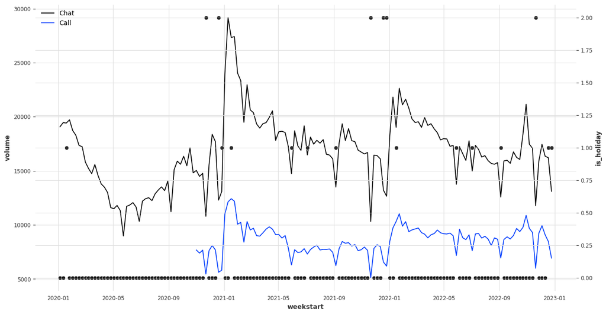

```python
# plot the weekly totals to check
plt.figure(figsize=(15,8))

ax=sns.lineplot(x='weekstart'
            ,y='volume'
            ,hue='interaction_type'
            ,data=weekly_df)
sns.scatterplot(ax=ax.twinx()
            ,x='weekstart'
            ,y='is_holiday'
            ,color='black'
            ,data=weekly_df)
ax.legend(loc='upper left')

plt.show()
```

```python
weekly_df
```

|  | weekstart | interaction_type | volume | is_holiday | is_workday |
| --- | --- | --- | --- | --- | --- |
| 0 | 2020-01-05 | Chat | 19069 | 0 | 5 |
| 1 | 2020-01-12 | Chat | 19453 | 0 | 5 |
| 2 | 2020-01-19 | Chat | 19414 | 1 | 4 |
| 3 | 2020-01-26 | Chat | 19712 | 0 | 5 |
| 4 | 2020-02-02 | Chat | 18725 | 0 | 5 |
| ... | ... | ... | ... | ... | ... |
| 264 | 2022-12-11 | Chat | 16345 | 0 | 5 |
| 265 | 2022-12-18 | Call | 8466 | 1 | 5 |
| 266 | 2022-12-18 | Chat | 16209 | 1 | 5 |
| 267 | 2022-12-25 | Call | 6924 | 1 | 4 |
| 268 | 2022-12-25 | Chat | 13101 | 1 | 4 |

269 rows × 5 columns

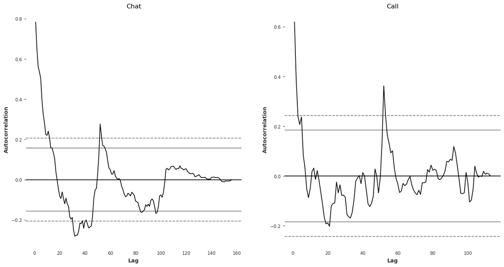

```python
# plot autocorrelations
fig, ax= plt.subplots(1,2,figsize=(16,8))

pd.plotting.autocorrelation_plot(weekly_df[weekly_df['interaction_type']=='Chat']['volume'], ax=ax[0])
ax[0].set_title('Chat')

pd.plotting.autocorrelation_plot(weekly_df[weekly_df['interaction_type']=='Call']['volume'], ax=ax[1])
ax[1].set_title('Call')

plt.show()
```

## Below: Functions for running models and plotting results

```python
##########################################################################################
# function definitions for future work--save these off
# function to easily fit and plot any model from the darts library

def fit_model(model, train, test):
    '''
    This function will fit any darts model to the training data and compare its performance to the
    test data. train and test must be existing TimeSeries objects.
    '''
    model.fit(train)
    forecast = model.predict(len(test))
    print("model {} obtains MAPE: {:.2f}%".format(model, met.mape(test, forecast)))

    # if there is a get_params() method, print the parameters
    try:
        print("model parameters:",str(model.model_params))
    except:
        print('No get_params() method for this model')

    train.plot(label='train')
    test.plot(label='test')

    # trim the model name if it's really long (many params reported)
    mname = str(model)
    if len(mname) >= 43:
        mname = mname[:40]+'...'

    forecast.plot(label=f'Forecast ({mname})')
    return model


def run_historical_forecasts(fitted_model, actual_series, start_param = 0.7, horizon_param = 2, save = False):
    '''
    This function takes a fitted model (which can be fitted with the fit_model function above)
    and runs the historical_forecasts function against it, returning the forecast and creating
    a plot of the actuals and historical forecast results, as well as the MAPE between the two.
    '''
    # fit the historical forecast
    hist_forecast = fitted_model.historical_forecasts(actual_series, start=start_param, forecast_horizon=horizon_param)

    # plot the results
    actual_series.plot(label='actuals')

    # trim the model name if it's really long (many params reported)
    mname = str(fitted_model)
    if len(mname) >= 43:
        mname = mname[:40]+'...'

    hist_forecast.plot(label=mname)

    # title the plot with info
    plt.title(f'Historical Forecast: {mname}; Horizon: {horizon_param} wks\n')

    # print the MAPE result
    print("model {} \nobtains MAPE: {:.2f}%".format(mname, met.mape(actual_series, hist_forecast)))

    if save:
        plt.savefig(mname+'.png', bbox_inches='tight')

    return hist_forecast
```

## Production models

First, reformat the volume data to be a 2-d timeseries object for chats and calls--dropping is_holiday because we're not using it

```python
# reformat the data
vol_df = weekly_df[['weekstart','interaction_type','volume']].copy()
vol_df = vol_df.pivot(columns='interaction_type', values='volume',index='weekstart')

# reset the name field of the columns because it causes darts ts conversion to fail
vol_df.columns.name=None
vol_df.head()
```

| weekstart | Call | Chat |
| --- | --- | --- |
| 2020-01-05 | NaN | 19069.0 |
| 2020-01-12 | NaN | 19453.0 |
| 2020-01-19 | NaN | 19414.0 |
| 2020-01-26 | NaN | 19712.0 |
| 2020-02-02 | NaN | 18725.0 |

```python
# convert the volume data to a darts TimeSeries object
vol_ts = darts.TimeSeries.from_dataframe(vol_df, freq = 'W')
vol_ts
```

```
<TimeSeries (DataArray) (weekstart: 156, component: 2, sample: 1)>
array([[[   nan],
        [19069.]],

       [[   nan],
        [19453.]],

       [[   nan],
        [19414.]],

       [[   nan],
        [19712.]],

       [[   nan],
        [18725.]],

       [[   nan],
        [18285.]],

       [[   nan],
        [17347.]],
...
       [[ 9292.],
        [17083.]],

       [[ 5980.],
        [11766.]],

       [[ 9215.],
        [15877.]],

       [[ 9917.],
        [17444.]],

       [[ 9071.],
        [16345.]],

       [[ 8466.],
        [16209.]],

       [[ 6924.],
        [13101.]]])
Coordinates:
  * weekstart  (weekstart) datetime64[ns] 2020-01-05 2020-01-12 ... 2022-12-25
  * component  (component) object 'Call' 'Chat'
Dimensions without coordinates: sample
Attributes:
    static_covariates:  None
    hierarchy:          None
```

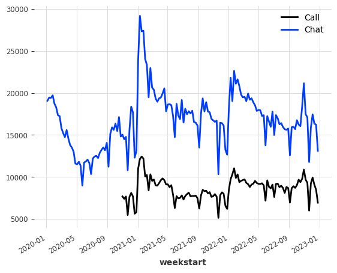

```python
vol_ts.plot()
```

```python
# create a test/train split
train, test = vol_ts.split_before(.8)
```

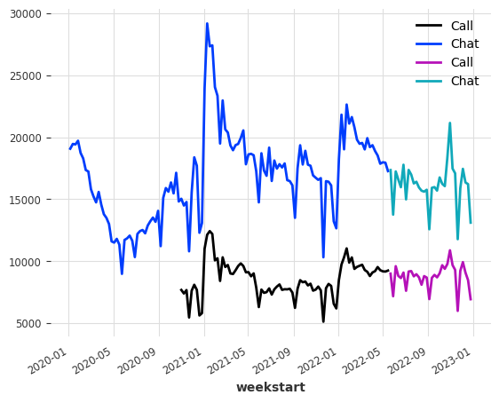

```python
train.plot()
test.plot()
```

## run best model previously identified for chat history

```
model SARIMA(1, 1, 1)x(1, 0, 0, 52) obtains MAPE: 6.34%
model parameters: OrderedDict([('p', 1), ('d', 1), ('q', 1), ('seasonal_order', (1, 0, 0, 52)), ('trend', None), ('random_state', 0)])
```

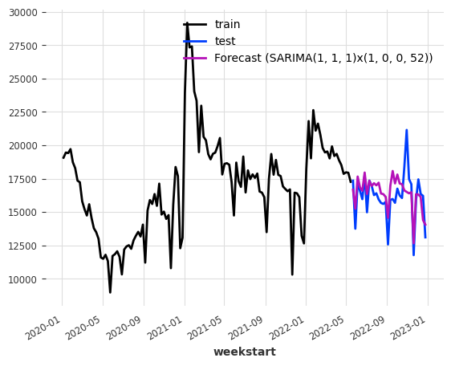

```python
# the best ARIMA model for chat history found in the AutoARIMA procedure was a (1,1,1)x(1,0,0)[52]. Let's see how that looks
best_ARIMA_chat = fit_model(mod.ARIMA(p=1,d=1,q=1, seasonal_order=(1,0,0,52)),
                           train = train['Chat'],
                           test = test['Chat'])
```

[output not shown]

```
model SARIMA(1, 1, 1)x(1, 0, 0, 52)
obtains MAPE: 5.53%
```

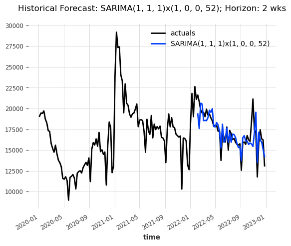

```python
# run the historical forecasting test on the best ARIMA model
ARIMA_chat_hist = run_historical_forecasts(best_ARIMA_chat, vol_ts['Chat'])
```

## run for calls

```
model SARIMA(0, 1, 3)x(1, 0, 0, 52) obtains MAPE: 7.86%
model parameters: OrderedDict([('p', 0), ('d', 1), ('q', 3), ('seasonal_order', (1, 0, 0, 52)), ('trend', None), ('random_state', 0)])
```

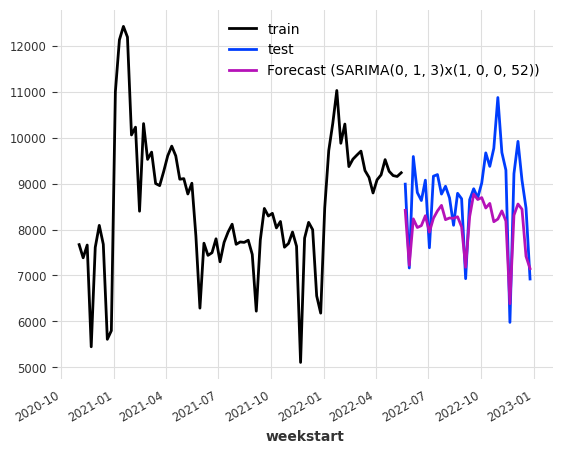

```python
# best model from above: ARIMA(0,1,3)(1,0,0)[52]
# fit it on the first test/train set and run historical
best_ARIMA_call = fit_model(mod.ARIMA(p=0,d=1,q=3, seasonal_order=(1,0,0,52)),
                          train = train['Call'],
                           test = test['Call'])
```

```
model SARIMA(0, 1, 3)x(1, 0, 0, 52)
obtains MAPE: 5.82%
```

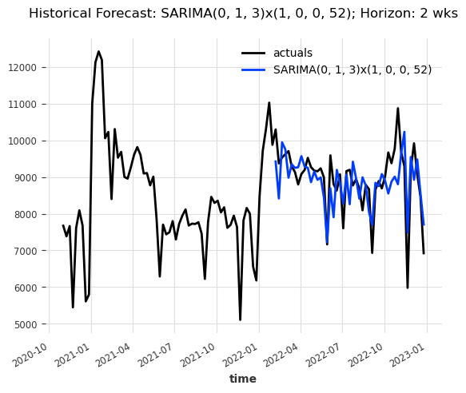

```python
# run historical forecast
ARIMA_call_hist = run_historical_forecasts(best_ARIMA_call, vol_ts['Call'])
```

## Now run both forecasts off full data and output

```python
def run_forecast(model, input_ts, forecast_horizon = 2, save=False):
    '''pass in a fitted model and the associated timeseries data, return
        a forecast time series and optionally save the output plot'''

    fitted_model = model.fit(input_ts)

    # run the forecast
    forecast = fitted_model.predict(forecast_horizon)

    # plot input actuals
    input_ts.plot(label='actual')

    # trim the model name if it's really long (many params reported)
    mname = str(fitted_model)
    if len(mname) >= 43:
        mname = mname[:40]+'...'

    # plot the forecast
    forecast.plot(label=f'Forecast ({mname})')

    # save the plot if desired
    if save:
        plt.savefig(mname+'_forecast.png', bbox_inches='tight')


    return forecast
```

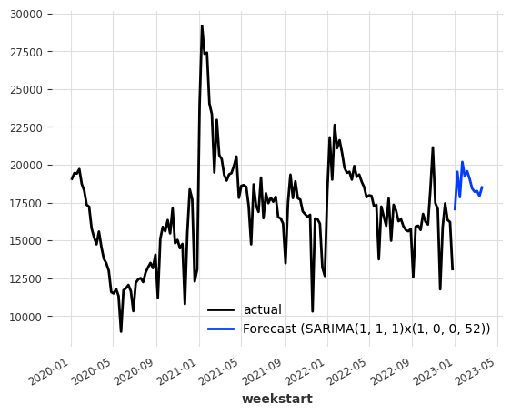

```python
chat_forecast = run_forecast(best_ARIMA_chat, vol_ts['Chat'], 12)
```

```python
chat_forecast
```

```
<TimeSeries (DataArray) (weekstart: 12, component: 1, sample: 1)>
array([[[17064.24094224]],

       [[19534.57202527]],

       [[17856.89987906]],

       [[20185.25875445]],

       [[19231.10874829]],

       [[19571.22444343]],

       [[19058.27898839]],

       [[18426.15800967]],

       [[18215.03887309]],

       [[18259.69755704]],

       [[17930.89080639]],

       [[18502.88259044]]])
Coordinates:
  * weekstart  (weekstart) datetime64[ns] 2023-01-01 2023-01-08 ... 2023-03-19
  * component  (component) object 'Chat'
Dimensions without coordinates: sample
Attributes:
    static_covariates:  None
    hierarchy:          None
```

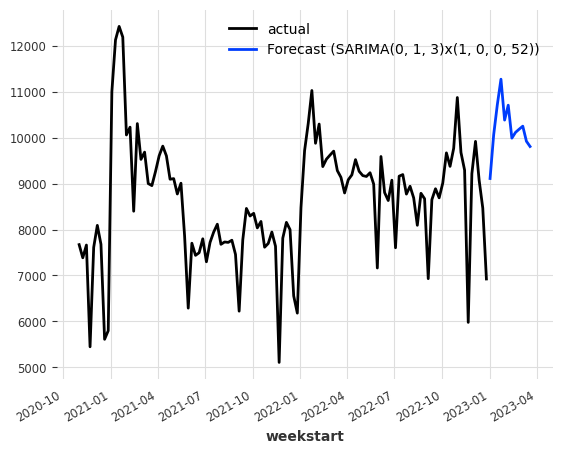

```python
call_forecast = run_forecast(best_ARIMA_call, vol_ts['Call'], 12)
```

# combine and output the forecast data

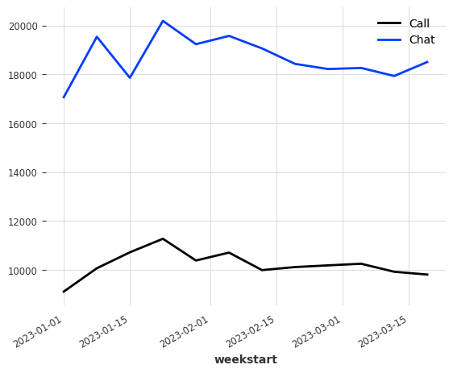

```python
# combine the forecasts into one timeseries
forecast_combine = call_forecast.stack(chat_forecast)
#forecast_combine = forecast_combine.with_columns_renamed(['Call','Chat'],['Call Forecast','Chat Forecast'])
forecast_combine.plot()
```

```python
# convert the data to a dataframe and add an indicator column
for_df = forecast_combine.pd_dataframe()
for_df['source'] = 'Forecast'

# add the same indicator to the actuals
vol_df['source'] = 'Actual'

out_df = pd.concat((vol_df,for_df))
out_df
```

| weekstart | Call | Chat | source |
| --- | --- | --- | --- |
| 2020-01-05 | NaN | 19069.000000 | Actual |
| 2020-01-12 | NaN | 19453.000000 | Actual |
| 2020-01-19 | NaN | 19414.000000 | Actual |
| 2020-01-26 | NaN | 19712.000000 | Actual |
| 2020-02-02 | NaN | 18725.000000 | Actual |
| ... | ... | ... | ... |
| 2023-02-19 | 10112.443594 | 18426.158010 | Forecast |
| 2023-02-26 | 10182.164597 | 18215.038873 | Forecast |
| 2023-03-05 | 10248.012212 | 18259.697557 | Forecast |
| 2023-03-12 | 9920.323495 | 17930.890806 | Forecast |
| 2023-03-19 | 9805.671177 | 18502.882590 | Forecast |

168 rows × 3 columns

```python
# rearrange our data to make the output a little nicer
calls=out_df[['Call','source']].rename(columns={'Call':'volume'}).reset_index()
calls.insert(1,'type','Call')


chats=out_df[['Chat','source']].rename(columns={'Chat':'volume'}).reset_index()
chats.insert(1,'type','Chat')
```

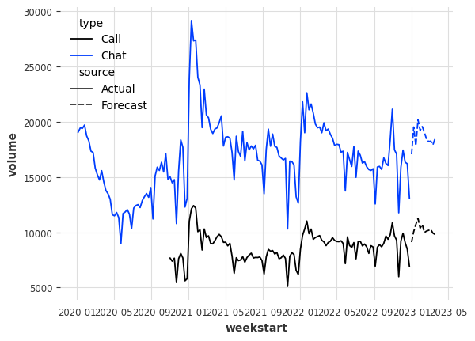

```python
# plot our output df just to be sure

forecast_df = pd.concat((calls,chats)).reset_index(drop=True)

sns.lineplot(x= 'weekstart'
            ,y= 'volume'
            ,hue='type'
            ,style='source'
            ,data = forecast_df)


plt.show()
```

# pull in averages by time block

Code here mostly copied from NAT-818 v3 notebook

```python
# get the last 8 weeks for averaging
tgt_date = raw_df['weekstart'].max() - pd.Timedelta(8,'W')

block_df = raw_df[raw_df['weekstart'] >= tgt_date].copy().reset_index(drop=True)

# add in an 'hour' column for use when averaging later
block_df['hour'] = block_df['bucket'].dt.strftime('%H:%M')


block_df
```

|  | weekstart | date | bucket | day_of_week | interaction_type | volume | is_holiday | is_workday | dayname | hour |
| --- | --- | --- | --- | --- | --- | --- | --- | --- | --- | --- |
| 0 | 2022-10-30 | 2022-10-31 | 2022-10-31 08:00:00 | 2 | Call | 29 | False | True | Monday | 08:00 |
| 1 | 2022-10-30 | 2022-10-31 | 2022-10-31 08:00:00 | 2 | Chat | 49 | False | True | Monday | 08:00 |
| 2 | 2022-10-30 | 2022-10-31 | 2022-10-31 08:30:00 | 2 | Call | 53 | False | True | Monday | 08:30 |
| 3 | 2022-10-30 | 2022-10-31 | 2022-10-31 08:30:00 | 2 | Chat | 122 | False | True | Monday | 08:30 |
| 4 | 2022-10-30 | 2022-10-31 | 2022-10-31 09:00:00 | 2 | Call | 69 | False | True | Monday | 09:00 |
| ... | ... | ... | ... | ... | ... | ... | ... | ... | ... | ... |
| 2855 | 2022-12-25 | 2022-12-31 | 2022-12-31 15:00:00 | 7 | Chat | 7 | False | False | Saturday | 15:00 |
| 2856 | 2022-12-25 | 2022-12-31 | 2022-12-31 15:30:00 | 7 | Call | 4 | False | False | Saturday | 15:30 |
| 2857 | 2022-12-25 | 2022-12-31 | 2022-12-31 15:30:00 | 7 | Chat | 3 | False | False | Saturday | 15:30 |
| 2858 | 2022-12-25 | 2022-12-31 | 2022-12-31 16:00:00 | 7 | Call | 2 | False | False | Saturday | 16:00 |
| 2859 | 2022-12-25 | 2022-12-31 | 2022-12-31 16:00:00 | 7 | Chat | 7 | False | False | Saturday | 16:00 |

2860 rows × 10 columns

```python
# adjust the volume to account for holiday weeks
adj_vol_df = vol_df.merge(day_counts, left_index=True, right_index=True)

# for weeks with 4 workdays, multiply volumes by a factor of 5/4
adj_vol_df['Call'] = adj_vol_df['Call'] * (5 / (5 - (adj_vol_df['is_workday'] < 5)))
adj_vol_df['Chat'] = adj_vol_df['Chat'] * (5 / (5 - (adj_vol_df['is_workday'] < 5)))

# adj_vol_df
```

```python
# join in the weekly totals from the input data
block_df = block_df.merge(adj_vol_df[['Call', 'Chat']], how ='left', left_on = 'weekstart', right_index=True)
```

```python
# ignore holidays as they may skew the percentages
# block_df = block_df[~ block_df['is_holiday']]
```

```python
# define a function to calculate the percentage volume conditional on interaction_type
def map_func(row):
    if row['interaction_type'] == 'Call':
        return row['volume'] / row['Call']
    elif row['interaction_type'] == 'Chat':
        return row['volume'] / row['Chat']
    else:
        return np.nan
```

```python
block_df
```

|  | weekstart | date | bucket | day_of_week | interaction_type | volume | is_holiday | is_workday | dayname | hour | Call | Chat |
| --- | --- | --- | --- | --- | --- | --- | --- | --- | --- | --- | --- | --- |
| 0 | 2022-10-30 | 2022-10-31 | 2022-10-31 08:00:00 | 2 | Call | 29 | False | True | Monday | 08:00 | 10871.0 | 21148.00 |
| 1 | 2022-10-30 | 2022-10-31 | 2022-10-31 08:00:00 | 2 | Chat | 49 | False | True | Monday | 08:00 | 10871.0 | 21148.00 |
| 2 | 2022-10-30 | 2022-10-31 | 2022-10-31 08:30:00 | 2 | Call | 53 | False | True | Monday | 08:30 | 10871.0 | 21148.00 |
| 3 | 2022-10-30 | 2022-10-31 | 2022-10-31 08:30:00 | 2 | Chat | 122 | False | True | Monday | 08:30 | 10871.0 | 21148.00 |
| 4 | 2022-10-30 | 2022-10-31 | 2022-10-31 09:00:00 | 2 | Call | 69 | False | True | Monday | 09:00 | 10871.0 | 21148.00 |
| ... | ... | ... | ... | ... | ... | ... | ... | ... | ... | ... | ... | ... |
| 2855 | 2022-12-25 | 2022-12-31 | 2022-12-31 15:00:00 | 7 | Chat | 7 | False | False | Saturday | 15:00 | 8655.0 | 16376.25 |
| 2856 | 2022-12-25 | 2022-12-31 | 2022-12-31 15:30:00 | 7 | Call | 4 | False | False | Saturday | 15:30 | 8655.0 | 16376.25 |
| 2857 | 2022-12-25 | 2022-12-31 | 2022-12-31 15:30:00 | 7 | Chat | 3 | False | False | Saturday | 15:30 | 8655.0 | 16376.25 |
| 2858 | 2022-12-25 | 2022-12-31 | 2022-12-31 16:00:00 | 7 | Call | 2 | False | False | Saturday | 16:00 | 8655.0 | 16376.25 |
| 2859 | 2022-12-25 | 2022-12-31 | 2022-12-31 16:00:00 | 7 | Chat | 7 | False | False | Saturday | 16:00 | 8655.0 | 16376.25 |

2860 rows × 12 columns

```python
# use the df.apply method to apply the function created above and calculate percent of weekly volume for each time period
block_df['volume_pct'] = block_df.apply(map_func, axis=1)
block_df.head()
```

|  | weekstart | date | bucket | day_of_week | interaction_type | volume | is_holiday | is_workday | dayname | hour | Call | Chat | volume_pct |
| --- | --- | --- | --- | --- | --- | --- | --- | --- | --- | --- | --- | --- | --- |
| 0 | 2022-10-30 | 2022-10-31 | 2022-10-31 08:00:00 | 2 | Call | 29 | False | True | Monday | 08:00 | 10871.0 | 21148.0 | 0.002668 |
| 1 | 2022-10-30 | 2022-10-31 | 2022-10-31 08:00:00 | 2 | Chat | 49 | False | True | Monday | 08:00 | 10871.0 | 21148.0 | 0.002317 |
| 2 | 2022-10-30 | 2022-10-31 | 2022-10-31 08:30:00 | 2 | Call | 53 | False | True | Monday | 08:30 | 10871.0 | 21148.0 | 0.004875 |
| 3 | 2022-10-30 | 2022-10-31 | 2022-10-31 08:30:00 | 2 | Chat | 122 | False | True | Monday | 08:30 | 10871.0 | 21148.0 | 0.005769 |
| 4 | 2022-10-30 | 2022-10-31 | 2022-10-31 09:00:00 | 2 | Call | 69 | False | True | Monday | 09:00 | 10871.0 | 21148.0 | 0.006347 |

```python
# drop the total weekly volume columns since they're no longer needed
# block_df.drop(columns=('Call','Chat'),inplace=True)
```

```python
# block_df.to_excel('testdata_8wkavg.xlsx')
```

```python
# calculate averages for each day/time period
group_cols = ['dayname','day_of_week','hour','interaction_type']

weekly_avgs = block_df[group_cols + ['volume_pct']].groupby(group_cols, as_index=False).mean()
weekly_avgs
```

|  | dayname | day_of_week | hour | interaction_type | volume_pct |
| --- | --- | --- | --- | --- | --- |
| 0 | Friday | 6 | 08:00 | Call | 0.002823 |
| 1 | Friday | 6 | 08:00 | Chat | 0.002508 |
| 2 | Friday | 6 | 08:30 | Call | 0.004698 |
| 3 | Friday | 6 | 08:30 | Chat | 0.004843 |
| 4 | Friday | 6 | 09:00 | Call | 0.006942 |
| ... | ... | ... | ... | ... | ... |
| 335 | Wednesday | 4 | 21:30 | Chat | 0.000232 |
| 336 | Wednesday | 4 | 22:00 | Call | 0.000236 |
| 337 | Wednesday | 4 | 22:00 | Chat | 0.000163 |
| 338 | Wednesday | 4 | 22:30 | Call | 0.000122 |
| 339 | Wednesday | 4 | 22:30 | Chat | 0.000186 |

340 rows × 5 columns

```python
# check that we average ~100% total for the week
interaction_totals = weekly_avgs.groupby('interaction_type').sum(numeric_only=True)
interaction_totals
```

| interaction_type | day_of_week | volume_pct |
| --- | --- | --- |
| Call | 740 | 0.975782 |
| Chat | 740 | 1.005616 |

```python
# adjust the percentages so that the averages all total to 100
weekly_avgs = weekly_avgs.merge(interaction_totals['volume_pct'].rename('adj factor'), left_on ='interaction_type', right_index=True)

weekly_avgs['adj_vol_pct'] = weekly_avgs['volume_pct'] / weekly_avgs['adj factor']

weekly_avgs.drop(columns='adj factor', inplace=True)

# check that the adjusted number now adds up to 1
weekly_avgs.groupby('interaction_type').sum(numeric_only=True)
```

| interaction_type | day_of_week | volume_pct | adj_vol_pct |
| --- | --- | --- | --- |
| Call | 740 | 0.975782 | 1.0 |
| Chat | 740 | 1.005616 | 1.0 |

```python
weekly_avgs
```

|  | dayname | day_of_week | hour | interaction_type | volume_pct | adj_vol_pct |
| --- | --- | --- | --- | --- | --- | --- |
| 0 | Friday | 6 | 08:00 | Call | 0.002823 | 0.002893 |
| 2 | Friday | 6 | 08:30 | Call | 0.004698 | 0.004815 |
| 4 | Friday | 6 | 09:00 | Call | 0.006942 | 0.007115 |
| 6 | Friday | 6 | 09:30 | Call | 0.007889 | 0.008085 |
| 8 | Friday | 6 | 10:00 | Call | 0.008651 | 0.008866 |
| ... | ... | ... | ... | ... | ... | ... |
| 331 | Wednesday | 4 | 20:30 | Chat | 0.000613 | 0.000610 |
| 333 | Wednesday | 4 | 21:00 | Chat | 0.000344 | 0.000342 |
| 335 | Wednesday | 4 | 21:30 | Chat | 0.000232 | 0.000230 |
| 337 | Wednesday | 4 | 22:00 | Chat | 0.000163 | 0.000162 |
| 339 | Wednesday | 4 | 22:30 | Chat | 0.000186 | 0.000185 |

340 rows × 6 columns

## Final part: combine the forecast output with the percentages to break into half-hours

```python
# test set that should match what we'll be working with in production form
forecast_df_test = forecast_df[forecast_df['source']=='Forecast'].sort_values(['weekstart','type']).head(4)
forecast_df_test
```

|  | weekstart | type | volume | source |
| --- | --- | --- | --- | --- |
| 156 | 2023-01-01 | Call | 9109.847705 | Forecast |
| 324 | 2023-01-01 | Chat | 17064.240942 | Forecast |
| 157 | 2023-01-08 | Call | 10063.234874 | Forecast |
| 325 | 2023-01-08 | Chat | 19534.572025 | Forecast |

```python
# merge the forecast with each day/time factor
keep_cols=['dayname', 'day_of_week', 'hour', 'interaction_type', 'adj_vol_pct']
final_df = forecast_df_test.merge(weekly_avgs[keep_cols], how='left', left_on='type', right_on='interaction_type')
```

```python
# apply the percentages
final_df['volume'] = final_df['volume'] * final_df['adj_vol_pct']
final_df.drop(columns=['interaction_type','adj_vol_pct'], inplace=True)
final_df
```

|  | weekstart | type | volume | source | dayname | day_of_week | hour |
| --- | --- | --- | --- | --- | --- | --- | --- |
| 0 | 2023-01-01 | Call | 26.357261 | Forecast | Friday | 6 | 08:00 |
| 1 | 2023-01-01 | Call | 43.859430 | Forecast | Friday | 6 | 08:30 |
| 2 | 2023-01-01 | Call | 64.812054 | Forecast | Friday | 6 | 09:00 |
| 3 | 2023-01-01 | Call | 73.654394 | Forecast | Friday | 6 | 09:30 |
| 4 | 2023-01-01 | Call | 80.767573 | Forecast | Friday | 6 | 10:00 |
| ... | ... | ... | ... | ... | ... | ... | ... |
| 675 | 2023-01-08 | Chat | 11.910073 | Forecast | Wednesday | 4 | 20:30 |
| 676 | 2023-01-08 | Chat | 6.679433 | Forecast | Wednesday | 4 | 21:00 |
| 677 | 2023-01-08 | Chat | 4.499428 | Forecast | Wednesday | 4 | 21:30 |
| 678 | 2023-01-08 | Chat | 3.159256 | Forecast | Wednesday | 4 | 22:00 |
| 679 | 2023-01-08 | Chat | 3.617180 | Forecast | Wednesday | 4 | 22:30 |

680 rows × 7 columns

```python
# add a date field
final_df['date'] = final_df['weekstart'] + pd.to_timedelta(final_df['day_of_week'] - 1, unit='days')
final_df
```

|  | weekstart | type | volume | source | dayname | day_of_week | hour | date |
| --- | --- | --- | --- | --- | --- | --- | --- | --- |
| 0 | 2023-01-01 | Call | 26.357261 | Forecast | Friday | 6 | 08:00 | 2023-01-06 |
| 1 | 2023-01-01 | Call | 43.859430 | Forecast | Friday | 6 | 08:30 | 2023-01-06 |
| 2 | 2023-01-01 | Call | 64.812054 | Forecast | Friday | 6 | 09:00 | 2023-01-06 |
| 3 | 2023-01-01 | Call | 73.654394 | Forecast | Friday | 6 | 09:30 | 2023-01-06 |
| 4 | 2023-01-01 | Call | 80.767573 | Forecast | Friday | 6 | 10:00 | 2023-01-06 |
| ... | ... | ... | ... | ... | ... | ... | ... | ... |
| 675 | 2023-01-08 | Chat | 11.910073 | Forecast | Wednesday | 4 | 20:30 | 2023-01-11 |
| 676 | 2023-01-08 | Chat | 6.679433 | Forecast | Wednesday | 4 | 21:00 | 2023-01-11 |
| 677 | 2023-01-08 | Chat | 4.499428 | Forecast | Wednesday | 4 | 21:30 | 2023-01-11 |
| 678 | 2023-01-08 | Chat | 3.159256 | Forecast | Wednesday | 4 | 22:00 | 2023-01-11 |
| 679 | 2023-01-08 | Chat | 3.617180 | Forecast | Wednesday | 4 | 22:30 | 2023-01-11 |

680 rows × 8 columns

```python
final_df['time_block']=pd.to_datetime(final_df['date'].astype(str)+' '+final_df['hour'])
```

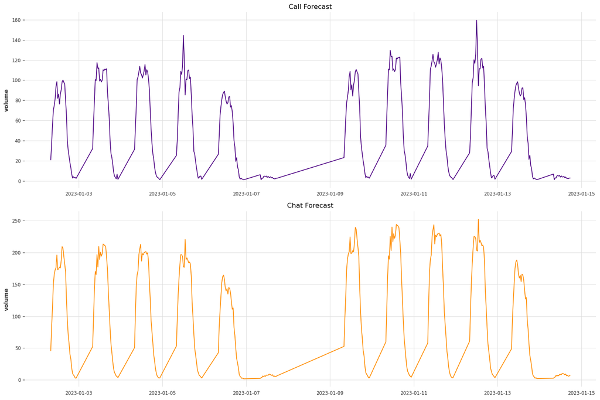

```python
# plot the results

fig,ax = plt.subplots(2,1, figsize=(15,10))

sns.lineplot(ax = ax[0]
            ,x='time_block'
            ,y='volume'
            ,color='indigo'
            ,data=final_df[final_df['type']=='Call'])
ax[0].set_title('Call Forecast')
ax[0].set_xlabel(None)

sns.lineplot(ax = ax[1]
            ,x='time_block'
            ,y='volume'
            ,color='darkorange'
            ,data=final_df[final_df['type']=='Chat'])
ax[1].set_title('Chat Forecast')
ax[1].set_xlabel(None)

fig.tight_layout()

plt.show()
```

**The above plot shows that the hourly percentage forecast methodology appears to work.** One point to note is that there is a significant spike in call volume for the Thursday 12:00 PM time block in both forecast weeks. This is due to a system outage which occured in the 12:00 PM Thursday block in early December, which caused an extraordinarily high volume of calls, skewing the overall average. This demonstrates the need for some robustness to outliers in the calculation of rolling average distribution. The next section will attempt to build this.

## Removing extreme outliers from rolling averages

```python
block_df.sort_values('volume',ascending=False).head(20)
```

|  | weekstart | date | bucket | day_of_week | interaction_type | volume | is_holiday | is_workday | dayname | hour | Call | Chat | volume_pct |
| --- | --- | --- | --- | --- | --- | --- | --- | --- | --- | --- | --- | --- | --- |
| 1782 | 2022-12-04 | 2022-12-08 | 2022-12-08 12:00:00 | 5 | Call | 553 | False | True | Thursday | 12:00 | 9917.0 | 17444.0 | 0.055763 |
| 1787 | 2022-12-04 | 2022-12-08 | 2022-12-08 13:00:00 | 5 | Chat | 492 | False | True | Thursday | 13:00 | 9917.0 | 17444.0 | 0.028205 |
| 1784 | 2022-12-04 | 2022-12-08 | 2022-12-08 12:30:00 | 5 | Call | 360 | False | True | Thursday | 12:30 | 9917.0 | 17444.0 | 0.036301 |
| 27 | 2022-10-30 | 2022-10-31 | 2022-10-31 14:30:00 | 2 | Chat | 276 | False | True | Monday | 14:30 | 10871.0 | 21148.0 | 0.013051 |
| 29 | 2022-10-30 | 2022-10-31 | 2022-10-31 15:00:00 | 2 | Chat | 271 | False | True | Monday | 15:00 | 10871.0 | 21148.0 | 0.012814 |
| 148 | 2022-10-30 | 2022-11-02 | 2022-11-02 15:30:00 | 4 | Chat | 267 | False | True | Wednesday | 15:30 | 10871.0 | 21148.0 | 0.012625 |
| 188 | 2022-10-30 | 2022-11-03 | 2022-11-03 10:30:00 | 5 | Chat | 265 | False | True | Thursday | 10:30 | 10871.0 | 21148.0 | 0.012531 |
| 15 | 2022-10-30 | 2022-10-31 | 2022-10-31 11:30:00 | 2 | Chat | 265 | False | True | Monday | 11:30 | 10871.0 | 21148.0 | 0.012531 |
| 90 | 2022-10-30 | 2022-11-01 | 2022-11-01 15:30:00 | 3 | Chat | 262 | False | True | Tuesday | 15:30 | 10871.0 | 21148.0 | 0.012389 |
| 361 | 2022-11-06 | 2022-11-07 | 2022-11-07 15:00:00 | 2 | Chat | 260 | False | True | Monday | 15:00 | 9676.0 | 17466.0 | 0.014886 |
| 136 | 2022-10-30 | 2022-11-02 | 2022-11-02 12:30:00 | 4 | Chat | 255 | False | True | Wednesday | 12:30 | 10871.0 | 21148.0 | 0.012058 |
| 192 | 2022-10-30 | 2022-11-03 | 2022-11-03 11:30:00 | 5 | Chat | 253 | False | True | Thursday | 11:30 | 10871.0 | 21148.0 | 0.011963 |
| 1084 | 2022-11-20 | 2022-11-22 | 2022-11-22 15:00:00 | 3 | Chat | 253 | False | True | Tuesday | 15:00 | 7475.0 | 14707.5 | 0.017202 |
| 25 | 2022-10-30 | 2022-10-31 | 2022-10-31 14:00:00 | 2 | Chat | 249 | False | True | Monday | 14:00 | 10871.0 | 21148.0 | 0.011774 |
| 142 | 2022-10-30 | 2022-11-02 | 2022-11-02 14:00:00 | 4 | Chat | 249 | False | True | Wednesday | 14:00 | 10871.0 | 21148.0 | 0.011774 |
| 78 | 2022-10-30 | 2022-11-01 | 2022-11-01 12:30:00 | 3 | Chat | 247 | False | True | Tuesday | 12:30 | 10871.0 | 21148.0 | 0.011680 |
| 86 | 2022-10-30 | 2022-11-01 | 2022-11-01 14:30:00 | 3 | Chat | 246 | False | True | Tuesday | 14:30 | 10871.0 | 21148.0 | 0.011632 |
| 146 | 2022-10-30 | 2022-11-02 | 2022-11-02 15:00:00 | 4 | Chat | 245 | False | True | Wednesday | 15:00 | 10871.0 | 21148.0 | 0.011585 |
| 190 | 2022-10-30 | 2022-11-03 | 2022-11-03 11:00:00 | 5 | Chat | 245 | False | True | Thursday | 11:00 | 10871.0 | 21148.0 | 0.011585 |
| 150 | 2022-10-30 | 2022-11-02 | 2022-11-02 16:00:00 | 4 | Chat | 245 | False | True | Wednesday | 16:00 | 10871.0 | 21148.0 | 0.011585 |

```python
from scipy import stats
```

```python
stats.zscore(block_df['volume']).sort_values(ascending=False)
```

```
1782    6.763128
1787    5.892825
1784    4.009546
27      2.811095
29      2.739759
          ...
508    -1.112403
507    -1.112403
505    -1.112403
1235   -1.112403
2210   -1.112403
Name: volume, Length: 2860, dtype: float64
```

```python
q=block_df[['interaction_type','volume']].groupby('interaction_type',as_index=False).quantile(0.99)
q.rename(columns={'volume':'99th pctile'},inplace=True)
q
```

|  | interaction_type | 99th pctile |
| --- | --- | --- |
| 0 | Call | 140.74 |
| 1 | Chat | 245.68 |

```python
outliers=block_df.merge(q,on='interaction_type')
outliers['ratio'] = outliers['volume']/outliers['99th pctile']
outliers[outliers['volume']>outliers['99th pctile']].sort_values('ratio',ascending =False)
```

|  | weekstart | date | bucket | day_of_week | interaction_type | volume | is_holiday | is_workday | dayname | hour | Call | Chat | volume_pct | 99th pctile | ratio |
| --- | --- | --- | --- | --- | --- | --- | --- | --- | --- | --- | --- | --- | --- | --- | --- |
| 887 | 2022-12-04 | 2022-12-08 | 2022-12-08 12:00:00 | 5 | Call | 553 | False | True | Thursday | 12:00 | 9917.0 | 17444.0 | 0.055763 | 140.74 | 3.929231 |
| 888 | 2022-12-04 | 2022-12-08 | 2022-12-08 12:30:00 | 5 | Call | 360 | False | True | Thursday | 12:30 | 9917.0 | 17444.0 | 0.036301 | 140.74 | 2.557908 |
| 2324 | 2022-12-04 | 2022-12-08 | 2022-12-08 13:00:00 | 5 | Chat | 492 | False | True | Thursday | 13:00 | 9917.0 | 17444.0 | 0.028205 | 245.68 | 2.002605 |
| 177 | 2022-11-06 | 2022-11-07 | 2022-11-07 15:00:00 | 2 | Call | 161 | False | True | Monday | 15:00 | 9676.0 | 17466.0 | 0.016639 | 140.74 | 1.143953 |
| 1440 | 2022-10-30 | 2022-10-31 | 2022-10-31 14:30:00 | 2 | Chat | 276 | False | True | Monday | 14:30 | 10871.0 | 21148.0 | 0.013051 | 245.68 | 1.123413 |
| 1207 | 2022-12-18 | 2022-12-22 | 2022-12-22 11:30:00 | 5 | Call | 157 | False | True | Thursday | 11:30 | 8466.0 | 16209.0 | 0.018545 | 140.74 | 1.115532 |
| 1441 | 2022-10-30 | 2022-10-31 | 2022-10-31 15:00:00 | 2 | Chat | 271 | False | True | Monday | 15:00 | 10871.0 | 21148.0 | 0.012814 | 245.68 | 1.103061 |
| 176 | 2022-11-06 | 2022-11-07 | 2022-11-07 14:30:00 | 2 | Call | 155 | False | True | Monday | 14:30 | 9676.0 | 17466.0 | 0.016019 | 140.74 | 1.101322 |
| 1502 | 2022-10-30 | 2022-11-02 | 2022-11-02 15:30:00 | 4 | Chat | 267 | False | True | Wednesday | 15:30 | 10871.0 | 21148.0 | 0.012625 | 245.68 | 1.086780 |
| 13 | 2022-10-30 | 2022-10-31 | 2022-10-31 14:30:00 | 2 | Call | 152 | False | True | Monday | 14:30 | 10871.0 | 21148.0 | 0.013982 | 140.74 | 1.080006 |
| 1434 | 2022-10-30 | 2022-10-31 | 2022-10-31 11:30:00 | 2 | Chat | 265 | False | True | Monday | 11:30 | 10871.0 | 21148.0 | 0.012531 | 245.68 | 1.078639 |
| 1522 | 2022-10-30 | 2022-11-03 | 2022-11-03 10:30:00 | 5 | Chat | 265 | False | True | Thursday | 10:30 | 10871.0 | 21148.0 | 0.012531 | 245.68 | 1.078639 |
| 41 | 2022-10-30 | 2022-11-01 | 2022-11-01 14:00:00 | 3 | Call | 151 | False | True | Tuesday | 14:00 | 10871.0 | 21148.0 | 0.013890 | 140.74 | 1.072900 |
| 1472 | 2022-10-30 | 2022-11-01 | 2022-11-01 15:30:00 | 3 | Chat | 262 | False | True | Tuesday | 15:30 | 10871.0 | 21148.0 | 0.012389 | 245.68 | 1.066428 |
| 73 | 2022-10-30 | 2022-11-02 | 2022-11-02 16:00:00 | 4 | Call | 150 | False | True | Wednesday | 16:00 | 10871.0 | 21148.0 | 0.013798 | 140.74 | 1.065795 |
| 1610 | 2022-11-06 | 2022-11-07 | 2022-11-07 15:00:00 | 2 | Chat | 260 | False | True | Monday | 15:00 | 9676.0 | 17466.0 | 0.014886 | 245.68 | 1.058287 |
| 71 | 2022-10-30 | 2022-11-02 | 2022-11-02 15:00:00 | 4 | Call | 148 | False | True | Wednesday | 15:00 | 10871.0 | 21148.0 | 0.013614 | 140.74 | 1.051584 |
| 1496 | 2022-10-30 | 2022-11-02 | 2022-11-02 12:30:00 | 4 | Chat | 255 | False | True | Wednesday | 12:30 | 10871.0 | 21148.0 | 0.012058 | 245.68 | 1.037936 |
| 526 | 2022-11-20 | 2022-11-22 | 2022-11-22 10:30:00 | 3 | Call | 146 | False | True | Tuesday | 10:30 | 7475.0 | 14707.5 | 0.019532 | 140.74 | 1.037374 |
| 95 | 2022-10-30 | 2022-11-03 | 2022-11-03 12:00:00 | 5 | Call | 146 | False | True | Thursday | 12:00 | 10871.0 | 21148.0 | 0.013430 | 140.74 | 1.037374 |
| 62 | 2022-10-30 | 2022-11-02 | 2022-11-02 10:30:00 | 4 | Call | 145 | False | True | Wednesday | 10:30 | 10871.0 | 21148.0 | 0.013338 | 140.74 | 1.030269 |
| 1524 | 2022-10-30 | 2022-11-03 | 2022-11-03 11:30:00 | 5 | Chat | 253 | False | True | Thursday | 11:30 | 10871.0 | 21148.0 | 0.011963 | 245.68 | 1.029795 |
| 1975 | 2022-11-20 | 2022-11-22 | 2022-11-22 15:00:00 | 3 | Chat | 253 | False | True | Tuesday | 15:00 | 7475.0 | 14707.5 | 0.017202 | 245.68 | 1.029795 |
| 37 | 2022-10-30 | 2022-11-01 | 2022-11-01 12:00:00 | 3 | Call | 143 | False | True | Tuesday | 12:00 | 10871.0 | 21148.0 | 0.013154 | 140.74 | 1.016058 |
| 1439 | 2022-10-30 | 2022-10-31 | 2022-10-31 14:00:00 | 2 | Chat | 249 | False | True | Monday | 14:00 | 10871.0 | 21148.0 | 0.011774 | 245.68 | 1.013514 |
| 1499 | 2022-10-30 | 2022-11-02 | 2022-11-02 14:00:00 | 4 | Chat | 249 | False | True | Wednesday | 14:00 | 10871.0 | 21148.0 | 0.011774 | 245.68 | 1.013514 |
| 14 | 2022-10-30 | 2022-10-31 | 2022-10-31 15:00:00 | 2 | Call | 142 | False | True | Monday | 15:00 | 10871.0 | 21148.0 | 0.013062 | 140.74 | 1.008953 |
| 1466 | 2022-10-30 | 2022-11-01 | 2022-11-01 12:30:00 | 3 | Chat | 247 | False | True | Tuesday | 12:30 | 10871.0 | 21148.0 | 0.011680 | 245.68 | 1.005373 |
| 63 | 2022-10-30 | 2022-11-02 | 2022-11-02 11:00:00 | 4 | Call | 141 | False | True | Wednesday | 11:00 | 10871.0 | 21148.0 | 0.012970 | 140.74 | 1.001847 |
| 1470 | 2022-10-30 | 2022-11-01 | 2022-11-01 14:30:00 | 3 | Chat | 246 | False | True | Tuesday | 14:30 | 10871.0 | 21148.0 | 0.011632 | 245.68 | 1.001303 |

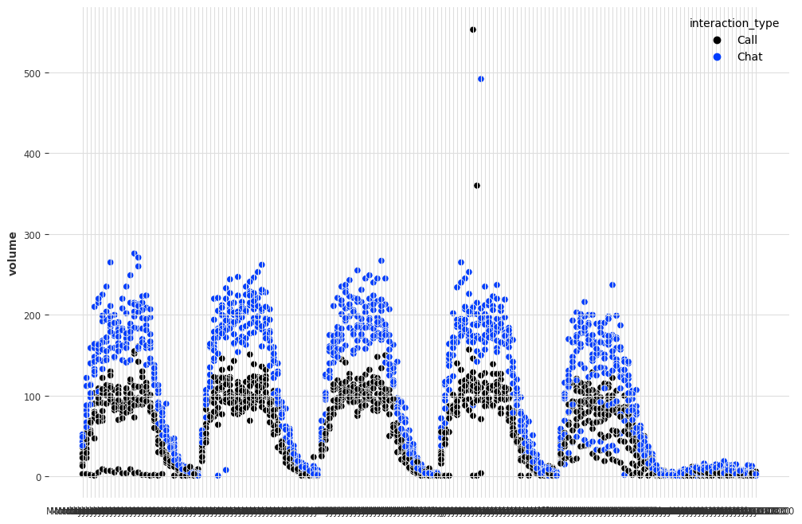

```python
plt.figure(figsize=(12,8))

sns.scatterplot(x=block_df['dayname']+' - '+block_df['hour']
               ,y=block_df['volume']
               ,hue=block_df['interaction_type'])
plt.show()
```

```python
# why does there appear to be a monday with no volume?
block_df[(block_df['volume']<10)&(block_df['dayname']=='Monday')].sort_values('bucket')
```

|  | weekstart | date | bucket | day_of_week | interaction_type | volume | is_holiday | is_workday | dayname | hour | Call | Chat | volume_pct |
| --- | --- | --- | --- | --- | --- | --- | --- | --- | --- | --- | --- | --- | --- |
| 48 | 2022-10-30 | 2022-10-31 | 2022-10-31 20:00:00 | 2 | Call | 5 | False | True | Monday | 20:00 | 10871.0 | 21148.00 | 0.000460 |
| 50 | 2022-10-30 | 2022-10-31 | 2022-10-31 20:30:00 | 2 | Call | 1 | False | True | Monday | 20:30 | 10871.0 | 21148.00 | 0.000092 |
| 52 | 2022-10-30 | 2022-10-31 | 2022-10-31 21:00:00 | 2 | Call | 2 | False | True | Monday | 21:00 | 10871.0 | 21148.00 | 0.000184 |
| 54 | 2022-10-30 | 2022-10-31 | 2022-10-31 21:30:00 | 2 | Call | 1 | False | True | Monday | 21:30 | 10871.0 | 21148.00 | 0.000092 |
| 55 | 2022-10-30 | 2022-10-31 | 2022-10-31 21:30:00 | 2 | Chat | 6 | False | True | Monday | 21:30 | 10871.0 | 21148.00 | 0.000284 |
| ... | ... | ... | ... | ... | ... | ... | ... | ... | ... | ... | ... | ... | ... |
| 2591 | 2022-12-25 | 2022-12-26 | 2022-12-26 17:30:00 | 2 | Call | 1 | True | False | Monday | 17:30 | 8655.0 | 16376.25 | 0.000116 |
| 2592 | 2022-12-25 | 2022-12-26 | 2022-12-26 18:00:00 | 2 | Call | 3 | True | False | Monday | 18:00 | 8655.0 | 16376.25 | 0.000347 |
| 2593 | 2022-12-25 | 2022-12-26 | 2022-12-26 19:30:00 | 2 | Call | 1 | True | False | Monday | 19:30 | 8655.0 | 16376.25 | 0.000116 |
| 2594 | 2022-12-25 | 2022-12-26 | 2022-12-26 21:00:00 | 2 | Call | 9 | True | False | Monday | 21:00 | 8655.0 | 16376.25 | 0.001040 |
| 2596 | 2022-12-25 | 2022-12-26 | 2022-12-26 22:00:00 | 2 | Call | 3 | True | False | Monday | 22:00 | 8655.0 | 16376.25 | 0.000347 |

94 rows × 13 columns